# DATA605: Final Project

Andrew Bowen

2023-04-30

## Problem 1

```r
set.seed(1234)
```

```r
n <- 5
lambda <- 8

X <- rgamma(1:10000, shape=n, scale=1/lambda)
```

Calculating our sum of exponential distributions: `Y` and `Z`:

```r
Y <- 0
for (i in 1:n){
  Y <- Y + rexp(1:10000, rate=lambda)
}

Z <- rexp(1:10000, rate=lambda)
```

#### Expected value and variance of our PDFs

```r
print(mean(X))
```

```
## [1] 0.6228281
```

```r
print(mean(Y))
```

```
## [1] 0.6242317
```

```r
print(mean(Z))
```

```
## [1] 0.1261022
```

```r
print(var(X))
```

```
## [1] 0.07520684
```

```r
print(var(Y))
```

```
## [1] 0.07647876
```

```r
print(var(Z))
```

```
## [1] 0.01464671
```

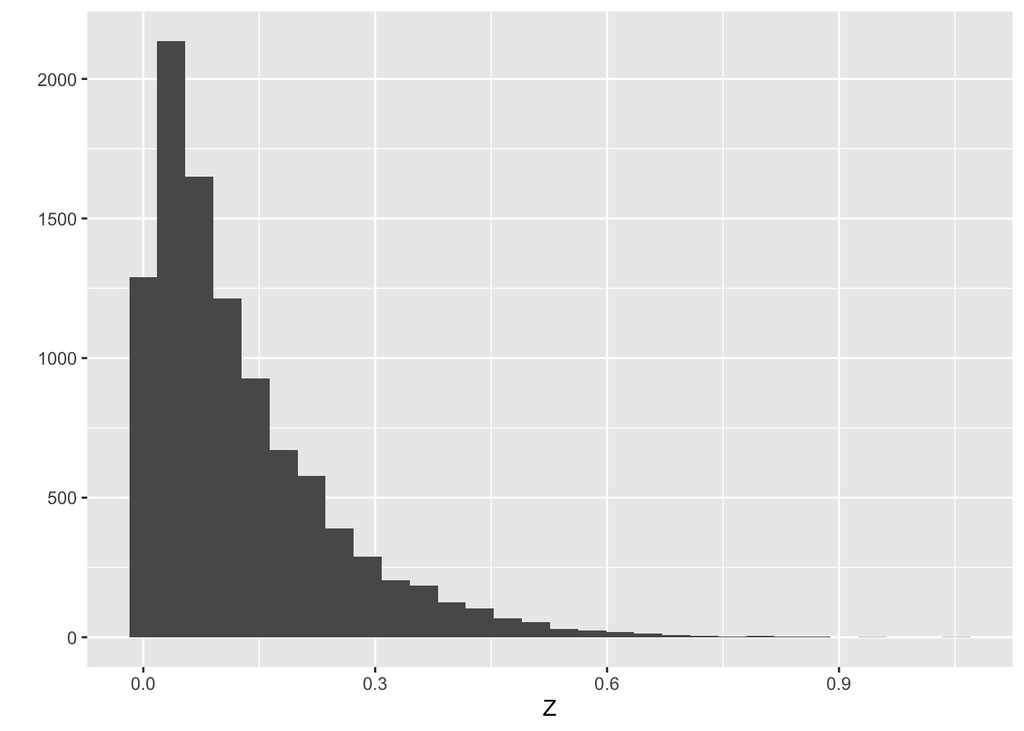

```r
qplot(Z)
```

### Question 1b

Using calculus, calculate the expected value and variance of the Gamma pdf ($X$). Using the moment generating function for exponentials, calculate the expected value of the single exponential (Z) and the sum of exponentials (Y)

#### Gamma Distirbution

For the gamma distribution, the pdf is

$$\begin{aligned}
f(x; \alpha, \beta) = \frac{x^{\alpha - 1}e^{-\beta
x}\beta^{\alpha}}{\Gamma(\alpha)}
\end{aligned}$$

where $\Gamma(\alpha) = (\alpha - 1)!$. We can find the expected value:

$$\begin{aligned}
E(X) = \int_0^{\infty} x \cdot \frac{x^{\alpha - 1}e^{-\beta
x}\beta^{\alpha}}{\Gamma(\alpha)} \,dx\newline
= \int_0^{\infty} \frac{\alpha}{\beta}\frac{\beta^{\alpha +
1}}{\Gamma(\alpha + 1)}x^{(\alpha + 1) - 1}e^{-\beta x} \,dx
\end{aligned}$$

We got to the step above using the fact that $\Gamma(a + 1) = a\Gamma(a)$. W ecan pull out our constants above and are left with the definition of the gamma distribution, which integrates to 1 over $(o, \infty)$

$$\begin{aligned}
E(X) = \frac{\alpha}{\beta}\int_0^{\infty} \frac{\beta^{\alpha +
1}}{\Gamma(\alpha + 1)}x^{(\alpha + 1) - 1}e^{-\beta x} \,dx
= \frac{\alpha}{\beta}
\end{aligned}$$

For the variance of the gamma distribution, we can use our calculation above, plugging into the formula $var(X) = E(X^2) - (E(X))^2$

$$\begin{aligned}
var(X) = \int_0^{\infty} x^2 f_X(x) \,dx - (E(X))^2\newline
= \int_0^{\infty} x^2 \frac{x^{\alpha - 1}e^{-\beta
x}\beta^{\alpha}}{\Gamma(\alpha)} \,dx -
\frac{\alpha^2}{\beta^2}\newline
=
\frac{\beta^{\alpha}}{\Gamma(\alpha)}\int_0^{\infty}(\frac{t}{\beta})^{\alpha
+ 1}e^{-t}/\beta \,dt - \frac{\alpha^2}{\beta^2}
\end{aligned}$$
Where we substituted $t = -\beta e$. Now we can simplify
$$\begin{aligned}
var(X) = \frac{\beta^{\alpha}}{\beta^{\alpha +
2}\Gamma(\alpha)}\int_0^{\infty} t^{\alpha + 1}e^t \,dt -
\frac{\alpha^2}{\beta^2} \newline
= \frac{\Gamma(\alpha + 2)}{\beta^2\Gamma(\alpha)} -
\frac{\alpha^2}{\beta^2}\newline
= \frac{\alpha(\alpha + 1)\Gamma(\alpha) -
\alpha^2\Gamma(\alpha)}{\beta^2\Gamma(\alpha])}\newline
= \frac{\alpha(\alpha + 1 - \alpha1)}{\beta^2} =
\frac{\alpha}{\beta^2}
\end{aligned}$$

#### Moment-generating function for exponentials

Let’s define our moment-generating function for the exponential distribution:

$$\begin{aligned}
M_Z(t) = \frac{1}{1 - \frac{t}{\lambda}}, t < \lambda
\end{aligned}$$
We know the moment generating function of the exponential distribution, so we just need to take its first derivative and evaluate at $t=0$
$$\begin{aligned}
\frac{\,dM}{\,dt} = \frac{d}{\,dt}(1 - \frac{t}{\lambda})^{-1} =
\frac{1}{\lambda(1 - \frac{t}{\lambda})^2}
\end{aligned}$$

When we evaluate the above at $t=0$, we get $1/\lambda$, roughly in line with what we expect from our simulated data ($1/8 = 0.125$)

```r
mean(Z)
```

```
## [1] 0.1261022
```

For the sum of exponentials (an [Erlang Distribution](https://en.wikipedia.org/wiki/Erlang_distribution)), we first need to figure out the moment generating function for the sum of exponentially-distributed random variables. We can use the property of moment generating functions that the sum of independent random variables produces a *product* moment generating function of the input variables $M_{X + Y}(t) = M_X(t)M_Y(t)$

$$\begin{aligned}
M_Y(t) = (\frac{1}{1 - \frac{t}{\lambda}})^n = (1 -
\frac{t}{\lambda})^{-n}
\end{aligned}$$

We can take the first derivative of this expression w.r.t $t$ and then evaluate at $t=0$ to find the expected value for our random variable $Y$

$$\begin{aligned}
M_Y(t)\rvert_{t=0} = \frac{d}{\,dt} = (1 -
\frac{t}{\lambda})^{-n}\rvert_{t=0} \newline
= -n(\frac{1}{1 - \frac{t}{\lambda}})^{-n -
1}(\frac{-1}{\lambda})\rvert_{t=0} = \frac{n}{\lambda(1 -
\frac{t}{\lambda})^{n + 1}}\rvert_{t=0}\newline
\frac{n}{\lambda}
\end{aligned}$$

This predicted value is pretty close to our simulated data mean

```r
print(n / lambda)
```

```
## [1] 0.625
```

```r
print(mean(Y))
```

```
## [1] 0.6242317
```

### Question 1c

$P(Z > \lambda | Z > \lambda /2)$

We can rewrite this as $P(Z > \lambda/2 ∩ Z > \lambda) / P(Z > \lambda/2)$. In this case, the numerator can be rewritten as $P(Z > \lambda/2 ∩ Z > \lambda) = P(Z > \lambda)$.We can then calculate our numerator and denominator expressions separately $P(Z > \lambda/2)$ & $P(Z > \lambda)$.

First, let’s find $P(Z > \lambda)$:

$$\begin{aligned}
P(Z > \lambda) = 1 - P(Z \le \lambda) = 1 - F(\lambda)\newline
= 1 - (1 - e^{-\lambda\lambda}) = e^{-\lambda}
\end{aligned}$$

We can use the cumulative distribution function for the exponential distribution $F(x) = 1 - e^{-\lambda x}$.

Similarly, we can find $P(Z > \lambda/2) = 1 - F(\lambda/2) = 1 - (1 - e^{-\lambda\lambda/2}) = e^{-\lambda/2}$. Dividing these, we get $e^{-\lambda / 2}$. Which we can plug in our value fo 8 to find the probability:

```r
(prob1c <- exp(-lambda / 2))
```

```
## [1] 0.01831564
```

#### Question 1d

Similar to above, we can re-write the expression as $P(Z > 2\lambda) / P(Z > \lambda)$.

$$\begin{aligned}
P(Z > 2\lambda) = 1 - (1 - e^{-\lambda2\lambda}) = e^{\lambda}
P(Z > \lambda) = 1 - (1 - e^-{\lambda\lambda}) = e^{-\lambda}
\end{aligned}$$

#### Question 1e

$P(Z>3\lambda | Z> \lambda)$

Similar to above, we can rewrite this expression:

$$\begin{aligned}
P(Z>3\lambda | Z> \lambda) = \frac{P(Z > \lambda \cap Z >
3\lambda)}{P(Z > \lambda)}\newline
= \frac{P(Z > 3\lambda)}{P(Z > \lambda)}
\end{aligned}$$

We already know from above that $P(Z > \lambda) = e^{-\lambda}$. We can then evaluate the numerator $P(Z > 3\lambda)$

$$\begin{aligned}
P(Z > 3\lambda) = 1 - (1 - e ^{-3\lambda}) = e^{-3\lambda}
\end{aligned}$$
Plugging into our joint probability, we get
$$\begin{aligned}
P(Z>3\lambda | Z> \lambda) = \frac{e^{-3\lambda}}{e^{-\lambda}}
= e^{-2\lambda}
\end{aligned}$$

```r
(prob1e <- exp(-2 * lambda))
```

```
## [1] 1.125352e-07
```

### Question 2

*Loosely investigate whether P(YZ) = P(Y) P(Z) by building a table with quartiles and evaluating the marginal and joint probabilities.* First, let’s get the different quartiles of our simulated values for Y and Z

```r
quartiles_to_keep <- c("25%", "50%", "75%", "100%")
(qY <- quantile(Y)[quartiles_to_keep])
```

```
##       25%       50%       75%      100%
## 0.4262256 0.5848759 0.7794643 2.2111061
```

```r
(qZ <- quantile(Z)[quartiles_to_keep])
```

```
##        25%        50%        75%       100%
## 0.03798518 0.08890607 0.17665073 1.05238332
```

Now let’s matrix multiply our simulated datasets to get the possible pairwise products of `Y` and `Z`. This is our “sample space” over our simulated data. In other words, this gives us bins into whihc out outcomes could fall into

```r
counts <- as.data.frame(qY %*% t(qZ))
rownames(counts) <- c("ZQ1", "ZQ2", "ZQ3", "ZQ4")
colnames(counts) <- c("YQ1", "YQ2", "YQ3", "YQ4")

N <- sum(counts)
(joint_probs <- counts / N)
```

```
##             YQ1         YQ2        YQ3        YQ4
## ZQ1 0.002983846 0.006983830 0.01387643 0.08266777
## ZQ2 0.004094498 0.009583363 0.01904154 0.11343850
## ZQ3 0.005456739 0.012771750 0.02537666 0.15117951
## ZQ4 0.015479130 0.036229620 0.07198596 0.42885087
```

We can verify that this is a valid marginal probability table by summing the rows and columns of our frequency table

```r
xx <- 0
yy <- 0

# sum rows to 1
for (i in 1:nrow(joint_probs)){xx <- xx + sum(joint_probs[i, ])}
# sum columns to 1
for (i in 1:nrow(joint_probs)){yy <- yy + sum(joint_probs[, i])}

# Check both sums are equal to 1
(xx == 1 & yy == 1)
```

```
## [1] TRUE
```

### Independence

```r
chisq.test(counts)
```

```
##
##  Pearson's Chi-squared test
##
## data:  counts
## X-squared = 7.7341e-32, df = 9, p-value = 1
```

Our p-value of 1 indicates that there is no relationship between $Y$ and $Z$(i.e., they **are** independent), and we cannot reject the null. This makes sense as `Y` and `Z` were simulated from different distribution calls in our code, and should be independent random vars.

Now we can run [Fisher’s exact test for independence](https://statsandr.com/blog/fisher-s-exact-test-in-r-independence-test-for-a-small-sample/), which is used typically with smaller samples

```r
ftest <- fisher.test(counts)
ftest
```

```
##
##  Fisher's Exact Test for Count Data
##
## data:  counts
## p-value = 1
## alternative hypothesis: two.sided
```

Similar to above, a p-value of 1 indicates we **cannot** reject the null hypothesis that our random variables are independent.